# UAOI extraction

```python
import pandas as pd
import geopandas as gpd
from geopandas.tools import sjoin
import pyproj
import shapely.geometry as geometry
import glob
import numpy as np
import matplotlib.pyplot as plt
import seaborn as sns
from shapely.ops import cascaded_union, polygonize
from scipy.spatial import Delaunay
import math
from matplotlib.collections import LineCollection
from descartes import PolygonPatch
pd.set_option('mode.chained_assignment',None)
```

## Data pre-processing

Read Flickr data that have downloaded followed the instruction in the 'Flickr data download' file. Preprocess the data to make it prepared for UAOI extraction. The process includes:

- Transform the Coordinate Reference System(CRS) of the raw geotagged Flickr data
- Conduct spatial analysis to select area within Inner London
- Subdivide time period to monthly time span
- Remove data noise

```python
f =  pd.read_csv('.../Flickr_data/15.csv')
#######select data located in Inner London
#The original geographic coordinates from Flickr is under WGS84,
#while the study area of Inner London is under UK datum, so need to transform WGS84 to OSGB36 first
wgs84 = pyproj.Proj("+init=EPSG:4326") # Lat/Lon with WGS84 datum used by GPS units and Google Earth
osgb36 = pyproj.Proj("+init=EPSG:27700") # UK Ordnance Survey, 1936 datum
X, Y = pyproj.transform(wgs84, osgb36, f.lon.values,f.lat.values)
f['X']= X
f['Y']= Y

#create a geometry column to enable spatial manipulation
f['geometry'] = gpd.GeoSeries([geometry.Point(x,y) for x, y in zip(f.X,f.Y)],index = f.index)
#write the file as geo file
f = gpd.GeoDataFrame(f,geometry = 'geometry')
f.crs ={'init': 'epsg:27700'}
#read innerlon shapefile
innerlon = gpd.read_file('.../Flickr_data/innerlon_nospace.shp')
innerlon.crs = {'init': 'epsg:27700'}
#pick up flickr data in inner london by intersecting points and polygon
f_within = sjoin(f,innerlon, how = 'inner')
f = f_within
```

```python
f.head()
```

|  | user | lat | lon | title | tag | date | X | Y | geometry | index_right | code | name | altname | label | Boundary | Source | Area_Ha | Shape_Leng | Shape_Area |
| --- | --- | --- | --- | --- | --- | --- | --- | --- | --- | --- | --- | --- | --- | --- | --- | --- | --- | --- | --- |
| 0 | 28229148@N05 | 51.507573 | -0.141334 | Christmas Spiral | shop departmentstore interiors spiral staircas... | 2015-01-01 20:08:45 | 529089.065504 | 180375.393647 | POINT (529089.065503914 180375.3936474545) | 10 | E09000033 | Westminster | None | E09000033 | Inner London | London Plan Consultation Draft | 34863.29569 | 117020.73749 | 3.486330e+08 |
| 7 | 40950430@N04 | 51.515849 | -0.142114 | doctor | street man london mask chinese pollution regen... | 2015-01-02 12:20:54 | 529011.573808 | 181294.341116 | POINT (529011.5738076445 181294.3411155805) | 10 | E09000033 | Westminster | None | E09000033 | Inner London | London Plan Consultation Draft | 34863.29569 | 117020.73749 | 3.486330e+08 |
| 12 | 122405397@N08 | 51.501104 | -0.126762 | Big Churchill | londres 2014 | 2015-01-01 15:35:44 | 530118.701066 | 179681.800429 | POINT (530118.7010660905 179681.8004291808) | 10 | E09000033 | Westminster | None | E09000033 | Inner London | London Plan Consultation Draft | 34863.29569 | 117020.73749 | 3.486330e+08 |
| 60 | 137431995@N08 | 51.507593 | -0.128467 | London new year parade 2015 | jan2015 | 2015-01-01 14:44:14 | 529981.914410 | 180400.372034 | POINT (529981.9144095747 180400.3720342041) | 10 | E09000033 | Westminster | None | E09000033 | Inner London | London Plan Consultation Draft | 34863.29569 | 117020.73749 | 3.486330e+08 |
| 92 | 25565317@N03 | 51.502344 | -0.143248 | London - Buckingham Palace - 2015.01.01 | NaN | 2015-01-01 14:07:54 | 528970.994597 | 179790.538696 | POINT (528970.9945970153 179790.538695662) | 10 | E09000033 | Westminster | None | E09000033 | Inner London | London Plan Consultation Draft | 34863.29569 | 117020.73749 | 3.486330e+08 |

```python
#subdivide the dataset by month
f_mon = []
f_mon10_12 = []
for i in range(12):
    f_mon.append(f.loc[(f.date >= '2015-0%s-01'%(i+1))&(f.date < '2015-0%s-01'%(i+2))])
    f_mon10_12.append(f.loc[(f.date >= '2015-%s-01'%(i+1))&(f.date < '2015-%s-01'%(i+2))])
f_mon[8] = f.loc[(f.date >= '2015-09-01')&(f.date < '2015-10-01')]
f_mon[9:12] = f_mon10_12[9:12]
```

```python
####remove noise in different time spans
#Same users upload photos at the same locations are duplicate records, keep only one
no_dup1 = [i.drop_duplicates(['user','X','Y'])for i in f_mon]
#Same users upload photos at the same second in different locations are impossible,
    #which are recognised as machine produced users, should be removed
no_dup2 = [j.drop_duplicates(['user','date'],keep = False) for j in no_dup1]
#convert string to datetime and then convert datetime to the time end with minutes
for i in range(12):
    no_dup2[i]['datetime']= pd.to_datetime(pd.Series(no_dup2[i].date,index = no_dup2[i].index))
    no_dup2[i]['date'] = no_dup2[i]['datetime'].dt.strftime('%Y-%m-%d %H:%M')
#Same users upload photos with the same tags in a minute should be used as a spatial filter
    #assume average walking speed is 5km/h. This is used to reduce the dominance of active users.
no_dup3 = [k.drop_duplicates(['user','date']) for k in no_dup2]

no_dup_points = no_dup3
```

## Clustering

Using HDBSCAN (hierarchical density-based spatial clustering applications with noise) algorithm, an improvement of DBSCAN, to extract UAOI at different time spans and then assign each cluster label to each photo record.

```python
##import HDBSCAN clustering package
import hdbscan

#use proportions of photo numbers to define min_cluster_size, create a list to store 12 min_cluster value for each month
c = [int(no_dup_points[i].shape[0] * 0.01) for i in range(12)]

#save the cluster label for each point
l = []
for i in range(12):
    clusterer = hdbscan.HDBSCAN(min_cluster_size = c[i], gen_min_span_tree = True,approx_min_span_tree = False)
    lbs = clusterer.fit_predict(no_dup_points[i][['X','Y']])
    l.append( pd.Series(lbs, index = no_dup_points[i].index))
    no_dup_points[i]['labels'] = l[i]
```

Visualise one month clustering result.

```
(519727.0541429529, 548939.7135979915, 168716.732714969, 189261.2099890619)
```

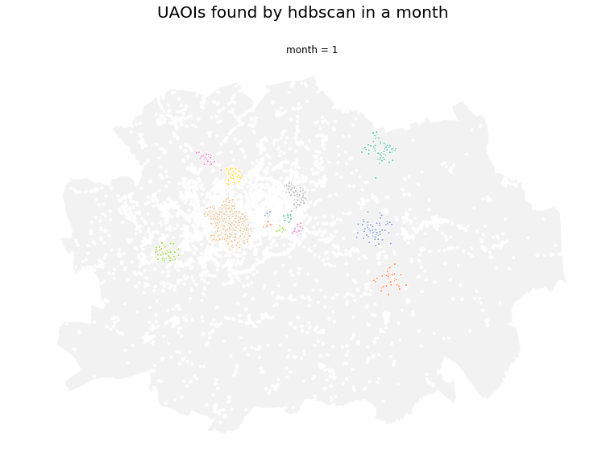

```python
#plot extracted UAOI based on HDBSCAN in January
f, ax = plt.subplots(1, figsize = (12,9))
innerlon.plot(ax = ax, alpha=0.1, linewidth=0.3, color = 'grey')
palette = sns.color_palette('Set2', np.unique(l[0]).max() + 1)
#show noise points as white
colors = [palette[x] if x != -1 else (1, 1, 1) for x in l[0]]
plt.scatter(no_dup_points[0].X,no_dup_points[0].Y, s = 10, c = colors, edgecolor = 'w')
plt.suptitle('UAOIs found by hdbscan in a month', fontsize=20)
plt.title('month = 1')
plt.axis('equal')
plt.axis('off')
```

# Drawing boundries for UAOI

Construct boundaries of UAOIs by using 'Alpha shapes' algorithm, a concave hull algorithm to enclose all points into areas. This process makes it possible to understand the dynamics of UAOIs later.

Define a function to perform alpha shapes algorithm, this function is from KEVIN DWYER's blog [link](http://blog.thehumangeo.com/2014/05/12/drawing-boundaries-in-python/)

```python
def alpha_shape(points, alpha):
    """
    Compute the alpha shape (concave hull) of a set
    of points.
    @param points: Iterable container of points.
    @param alpha: alpha value to influence the
        gooeyness of the border. Smaller numbers
        don't fall inward as much as larger numbers.
        Too large, and you lose everything!
    """
    if len(points) < 4:
        # When you have a triangle, there is no sense
        # in computing an alpha shape.
        return geometry.MultiPoint(list(points)).convex_hull
    def add_edge(edges, edge_points, coords, i, j):
        """
        Add a line between the i-th and j-th points,
        if not in the list already
        """
        if (i, j) in edges or (j, i) in edges:
            # already added
            return
        edges.add( (i, j) )
        edge_points.append(coords[ [i, j] ])
    coords = np.array([point.coords[0]
                       for point in points])
    tri = Delaunay(coords)
    edges = set()
    edge_points = []
    # loop over triangles:
    # ia, ib, ic = indices of corner points of the triangle
    for ia, ib, ic in tri.vertices:
        pa = coords[ia]
        pb = coords[ib]
        pc = coords[ic]
        # Lengths of sides of triangle
        a = math.sqrt((pa[0]-pb[0])**2 + (pa[1]-pb[1])**2)
        b = math.sqrt((pb[0]-pc[0])**2 + (pb[1]-pc[1])**2)
        c = math.sqrt((pc[0]-pa[0])**2 + (pc[1]-pa[1])**2)
        # Semiperimeter of triangle
        s = (a + b + c)/2.0
        # Area of triangle by Heron's formula
        area = math.sqrt(s*(s-a)*(s-b)*(s-c))
        circum_r = a*b*c/(4.0*area)
        # Here's the radius filter.
        #print circum_r
        if circum_r < 1.0/float(alpha):
            add_edge(edges, edge_points, coords, ia, ib)
            add_edge(edges, edge_points, coords, ib, ic)
            add_edge(edges, edge_points, coords, ic, ia)
    m = geometry.MultiLineString(edge_points)
    triangles = list(polygonize(m))
    return cascaded_union(triangles), edge_points
```

```python
#Append different points geometry based on labels, and convert point geometry to array in order to implement alpha shape
aoi = [[] for x in range(12)]
for i in range(12):
    for j in range(no_dup_points[i]['labels'].max()+1):
        p = no_dup_points[i].loc[no_dup_points[i]['labels'] == j]
        aoi[i].append(np.array(p.geometry))# for alpha shape
```

```python
#plot one AOI in the first month based on hdbscan
concave_hull, edge_points = alpha_shape(aoi[0][0],alpha=.003)
concave_hull
```

[output not shown]

Visualise all enclosed UAOIs in Januray

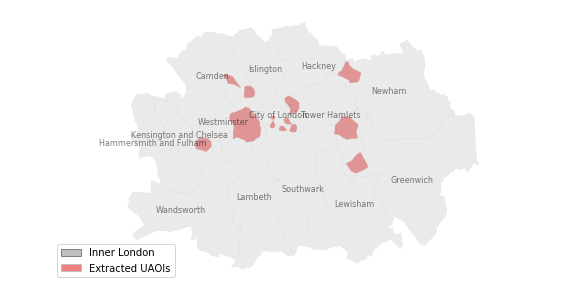

```python
#plot one month result after performing Alpha Shapes on the extracted UAOIs
f, ax = plt.subplots(1,figsize = (9,5))
innerlon.plot(ax = ax, alpha=0.34, linewidth=0.1, edgecolor = 'gray', facecolor = 'silver')
#add a legend
import matplotlib.patches as mpatches
lon = mpatches.Patch(edgecolor = 'grey', facecolor = 'silver', label='Inner London')
ex_aoi = mpatches.Patch(fc='lightcoral', ec='silver', label='Extracted UAOIs')
plt.legend(handles=[lon,ex_aoi], loc=3)
#create a new colomn for inner_london, in order to plot polygon labels (i.e. name) in the map
innerlon['coords']=innerlon['geometry'].apply(lambda x:x.representative_point().coords[:])
innerlon['coords']=[coords[0] for coords in innerlon['coords']]
poly=innerlon[['name','coords']]
for idx, row in poly.iterrows():
    ax.annotate(s=row['name'],xy=row['coords'],va='center',ha='center',alpha = 0.5, fontsize = 8)
#plot multiple AOIs at one time
for j in range(no_dup_points[0]['labels'].max()+1):
    concave_hull, edge_points = alpha_shape(aoi[0][j],alpha= 0.002)
    b = concave_hull.buffer(10)
    patch = PolygonPatch(b, fc='lightcoral', ec='silver', fill=True, zorder=-1, alpha =1,linewidth = 0.1)
    ax.add_patch(patch)
    plt.axis('equal')
    plt.axis('off')
```

## Save as shapefile

Save all UAOI geometry in a geodataframe which can be done in 'geopandas' package, and write them into a shapefile.

```python
# calcaulte the areas of all UAOIs in just one month
aoi_poly = []

for j in range(no_dup_points[0]['labels'].max()+1):
    concave_hull, edge_points = alpha_shape(aoi[0][j],alpha = .003)
    aoi_poly.append(concave_hull)
```

```python
#create a geodataframe to put all UAOIs geometry, time information, and area in a shapefile
gdf = gpd.GeoDataFrame(geometry = aoi_poly,crs = innerlon.crs)
gdf['month'] = 1
```

```python
gdf.to_file(driver = 'ESRI Shapefile', filename= "poly1.shp")
```